# Spatial multi-cellular motifs with smotif

This vignette walks through the end-to-end `smotif` workflow on the prepared workshop Xenium dataset (a small human lung cancer FFPE slide). The data is loaded from prebuilt parquet shipped in `inst/extdata/workshop_xenium/`; `Giotto` is a Suggests-only dependency and the package itself never re-runs the ingestion. Cell-type labels in this vignette are the LLM-fallback `cluster_<n>` strings — set `ANTHROPIC_API_KEY` and rerun `inst/scripts/prepare_workshop_xenium.R` to get real cell-type names.

## 1. Load the prepared SpatialGraph

```r
library(smotif)
library(ggplot2)
ext <- system.file("extdata", "workshop_xenium", package = "smotif")
sg <- read_spatial_graph(
  file.path(ext, "nodes.parquet"),
  file.path(ext, "edges.parquet")
)
print(sg)
```

```
#> <SpatialGraph>
#>   nodes: 7586  |  edges: 26304  |  build: read_spatial_graph
#>   samples (1): workshop_xenium
#>   regions (3): niche_1=4750, niche_3=1706, niche_2=1130
#>   cell types (9, top 5): cluster_4=1610, cluster_2=1390, cluster_1=1045, cluster_3=957, cluster_6=753
```

## 2. Tissue layout

The slide is small (~7.5k cells) and roughly 1 mm × 0.8 mm. Coloring by cluster identity reveals the cell-type composition; coloring the same points by `region_id` shows the niche segmentation that `prepare_workshop_xenium.R` derived from cell-type composition over spatial neighbors:

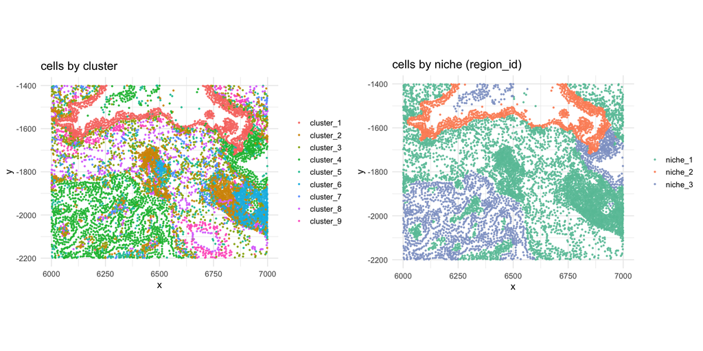

```r
nodes_df <- as.data.frame(sg$nodes)

p_ct <- ggplot(nodes_df, aes(x = x, y = y, color = cell_type)) +
  geom_point(size = 0.4, alpha = 0.85) +
  coord_fixed() +
  labs(title = "cells by cluster", color = NULL) +
  theme_minimal(base_size = 9) +
  theme(legend.key.size = unit(0.4, "cm"))

p_rg <- ggplot(nodes_df, aes(x = x, y = y, color = region_id)) +
  geom_point(size = 0.4, alpha = 0.85) +
  scale_color_brewer(palette = "Set2") +
  coord_fixed() +
  labs(title = "cells by niche (region_id)", color = NULL) +
  theme_minimal(base_size = 9) +
  theme(legend.key.size = unit(0.4, "cm"))

# side-by-side using patchwork-free plain layout:
gridExtra::grid.arrange(p_ct, p_rg, ncol = 2)
```

## 3. Find size-2 and size-3 motifs

```r
m2 <- find_motifs(sg, size = 2L)
m3 <- find_motifs(sg, size = 3L)
m3$catalog[order(-count)][1:5,
  .(motif_id, canonical_iso_class, count)]
```

```
#>                                      motif_id canonical_iso_class count
#>                                        <char>              <char> <int>
#> 1:   size3_open_cluster_4-cluster_4_cluster_4               wedge 12296
#> 2:   size3_open_cluster_1-cluster_1_cluster_1               wedge  8478
#> 3:   size3_open_cluster_2-cluster_2_cluster_2               wedge  4780
#> 4:   size3_open_cluster_6-cluster_6_cluster_6               wedge  4107
#> 5: size3_closed_cluster_4-cluster_4-cluster_4            triangle  4042
```

```r
stopifnot(sum(m2$catalog$count) == nrow(sg$edges))
m3$catalog[, .(types = .N, total = sum(count)),
           by = canonical_iso_class]
```

```
#>    canonical_iso_class types total
#>                 <char> <int> <int>
#> 1:            triangle   145 25443
#> 2:               wedge   353 83420
```

## 4. Where does a motif live in space?

Each `Motifs` instance has an `incidence` table linking instances to the `cell_id`s that participate. We can map any motif onto the slide by counting, per cell, how many instances of that motif touch it. This turns the abstract motif catalog into a tissue-level heatmap.

```r
motif_density <- function(motifs, motif_id_target) {
  inc <- motifs$incidence[motif_id == motif_id_target,
                          .(n_instances = .N), by = cell_id]
  merge(as.data.frame(sg$nodes)[, c("cell_id", "x", "y")],
        inc, by = "cell_id", all.x = TRUE) |>
    transform(n_instances = ifelse(is.na(n_instances), 0L,
                                   n_instances))
}

top_motif_id <- m3$catalog[which.max(count), motif_id]
top_density  <- motif_density(m3, top_motif_id)
top_motif_id
```

```
#> [1] "size3_open_cluster_4-cluster_4_cluster_4"
```

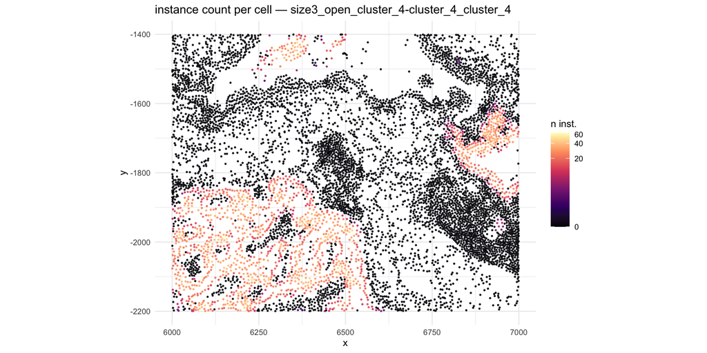

```r
p_motif <- ggplot(top_density, aes(x = x, y = y, color = n_instances)) +
  geom_point(size = 0.4, alpha = 0.85) +
  scale_color_viridis_c(option = "magma", trans = "log1p") +
  coord_fixed() +
  labs(title = sprintf("instance count per cell — %s", top_motif_id),
       color = "n inst.") +
  theme_minimal(base_size = 9)

p_motif
```

The most common motif (a cluster_4 self-self-self wedge) lights up exactly the cluster_4-dominated band, as expected. Boring on its own, but a useful sanity check that incidence and coordinates line up.

## 5. Enrichment under a global label-permutation null

```r
e_global <- test_motif_enrichment(
  m3, sg,
  null = "label_permutation",
  n_perm = 200L, seed = 1L
)
head(e_global, 5)[,
  .(motif_id, observed, mean_null, z, p_emp, fold)]
```

```
#>                                      motif_id observed mean_null        z
#>                                        <char>    <int>     <num>    <num>
#> 1:   size3_open_cluster_9-cluster_9_cluster_9     1164     4.185 482.0142
#> 2: size3_closed_cluster_9-cluster_9-cluster_9      563     1.260 466.5563
#> 3:   size3_open_cluster_1-cluster_1_cluster_1     8478   219.555 363.4102
#> 4:   size3_open_cluster_6-cluster_6_cluster_6     4107    80.605 295.7502
#> 5:   size3_open_cluster_4-cluster_4_cluster_4    12296   788.255 276.4429
#>          p_emp      fold
#>          <num>     <num>
#> 1: 0.004975124 278.13620
#> 2: 0.004975124 446.82540
#> 3: 0.004975124  38.61447
#> 4: 0.004975124  50.95217
#> 5: 0.004975124  15.59901
```

## 6. Region-stratified vs unstratified

```r
e_strat <- test_motif_enrichment(
  m3, sg,
  null = "region_stratified",
  n_perm = 200L, seed = 1L
)
joined <- merge(
  e_global[, .(motif_id, p_global = p_emp, z_global = z, m_global = mean_null)],
  e_strat[,  .(motif_id, p_strat  = p_emp, z_strat  = z, m_strat  = mean_null)],
  by = "motif_id"
)
head(joined[order(p_strat)], 5)
```

```
#>                                      motif_id    p_global   z_global m_global
#>                                        <char>       <num>      <num>    <num>
#> 1: size3_closed_cluster_1-cluster_1-cluster_1 0.004975124 255.391013   66.625
#> 2: size3_closed_cluster_1-cluster_3-cluster_3 1.000000000  -6.376902  165.215
#> 3: size3_closed_cluster_2-cluster_2-cluster_2 0.004975124  70.853183  156.615
#> 4: size3_closed_cluster_2-cluster_3-cluster_3 0.004975124  17.803691  223.405
#> 5: size3_closed_cluster_2-cluster_5-cluster_5 0.004975124  12.385734  128.675
#>        p_strat   z_strat  m_strat
#>          <num>     <num>    <num>
#> 1: 0.004975124 10.301485 2451.580
#> 2: 0.004975124  6.113501   21.385
#> 3: 0.004975124 39.612811  349.375
#> 4: 0.004975124  3.411910  483.920
#> 5: 0.004975124  7.834222  188.530
```

The two nulls disagree most where the global null is too generous — i.e. where the unstratified shuffle ignores the niche structure that already concentrates same-cluster cells. The scatter below makes the shrinkage explicit:

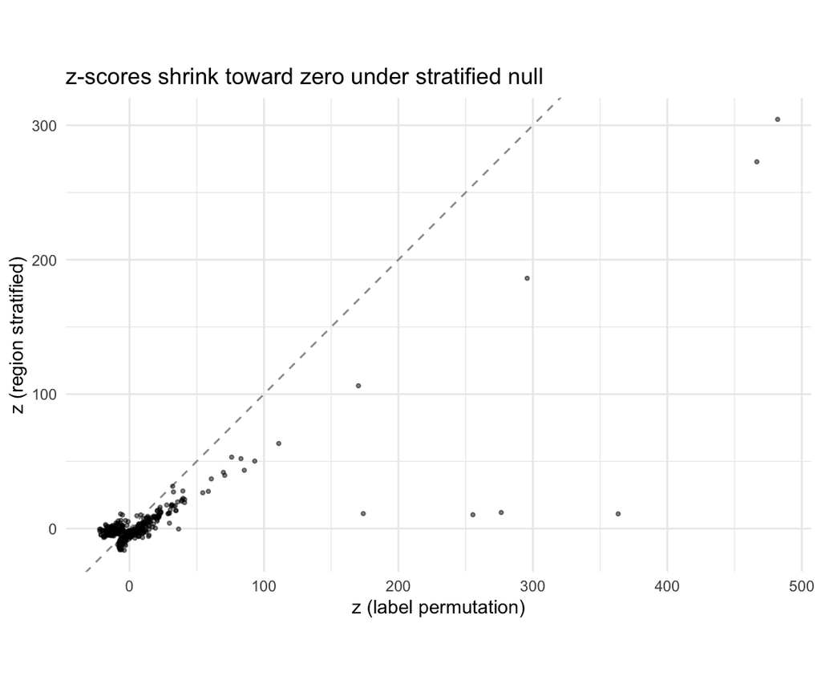

```r
plot_null <- ggplot(joined, aes(x = z_global, y = z_strat)) +
  geom_abline(slope = 1, intercept = 0, color = "grey60",
              linetype = "dashed") +
  geom_point(alpha = 0.5, size = 0.7) +
  coord_fixed() +
  labs(x = "z (label permutation)", y = "z (region stratified)",
       title = "z-scores shrink toward zero under stratified null") +
  theme_minimal(base_size = 10)
plot_null
```

## 7. Top-enriched motif → associated genes

```r
expr <- readRDS(file.path(ext, "expression.rds"))
top_strat_motif <- e_strat[which.min(p_emp), motif_id]
g <- associate_genes(
  m3, expr, sg,
  method = "wilcoxon",
  min_cells = 30L, min_in_expressed = 5L
)
head(g[motif_id == top_strat_motif][order(p)],
     10)[, .(gene, n_in, mean_in, mean_out, log2FC, z, p_adj_BH)]
```

```
#>        gene  n_in    mean_in   mean_out     log2FC          z p_adj_BH
#>      <char> <int>      <num>      <num>      <num>      <num>    <num>
#>  1:   ACTA2   254 2.12992126 0.15043644  1.4439451  34.525863        0
#>  2:   ACTG2   254 1.45669291 0.30987452  0.9072889  14.609131        0
#>  3: ADAMTS1   254 1.67322835 0.28982542  1.0514073  23.212134        0
#>  4:    ASPN   254 0.26377953 0.07337698  0.2355880   8.303781        0
#>  5:   BASP1   254 0.05118110 0.96426623 -0.9019792 -12.228416        0
#>  6:   CAPN8   254 0.02755906 1.15889253 -1.0710701  -8.325926        0
#>  7:    CAV1   254 0.23622047 0.06123841  0.2201873   9.800233        0
#>  8:  CAVIN1   254 0.71259843 0.32105837  0.3744927   9.259835        0
#>  9:    CNN1   254 0.96062992 0.01800327  0.9455750  47.435240        0
#> 10:   CXCR4   254 0.01968504 0.79064375 -0.8123547 -11.198516        0
```

## 8. Per-sample meta-analysis

Pooling cells across samples (the default in §7) conflates two very different patterns: a gene that’s consistently enriched in motif cells across every sample versus a gene that’s enriched in only *one* sample with a large effect. `pooling = "per_sample"` runs the Wilcoxon test inside each sample and combines via Stouffer-weighted Z. The combined statistic still favors true reproducible signals; the new `sd_log2FC` column flags heterogeneous ones.

The workshop slide is a single sample, so to demonstrate the workflow we split it into three spatial *pseudo-samples* by x-coordinate quantiles. Cross-tile edges are dropped so each tile is a self-contained spatial graph. With pseudo-samples drawn from the same underlying biology, `sd_log2FC` should be small for genuine signals — the diagnostic value of the metric is most visible on real multi-sample data, but the workflow is identical:

```r
new_nodes <- data.table::copy(sg$nodes)
xq <- stats::quantile(new_nodes$x, probs = c(0, 1/3, 2/3, 1))
new_nodes[, sample_id := as.character(cut(
  x, breaks = xq, labels = c("tile_A", "tile_B", "tile_C"),
  include.lowest = TRUE
))]
new_edges <- data.table::copy(sg$edges)
src_tile <- new_nodes[match(new_edges$source, cell_id), sample_id]
tgt_tile <- new_nodes[match(new_edges$target, cell_id), sample_id]
keep <- src_tile == tgt_tile
new_edges <- new_edges[keep]
new_edges[, sample_id := src_tile[keep]]
sg_pseudo <- SpatialGraph(
  new_nodes, new_edges,
  meta = list(build_method = "pseudo_split")
)
```

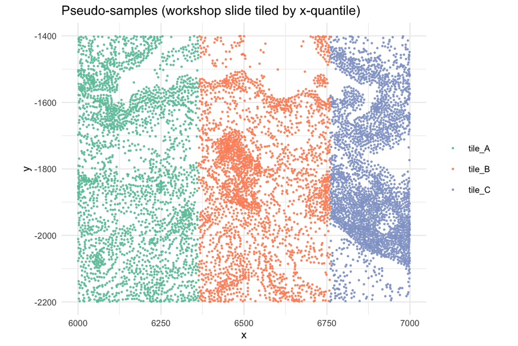

```r
ggplot(as.data.frame(sg_pseudo$nodes),
       aes(x = x, y = y, color = sample_id)) +
  geom_point(size = 0.4, alpha = 0.85) +
  scale_color_brewer(palette = "Set2") +
  coord_fixed() +
  labs(title = "Pseudo-samples (workshop slide tiled by x-quantile)",
       color = NULL) +
  theme_minimal(base_size = 9)
```

Now find motifs on the pseudo-multi-sample graph and run both pooling modes for the same `min_cells` settings:

```r
m_pseudo <- find_motifs(sg_pseudo, size = 3L)
res_pooled <- associate_genes(
  m_pseudo, expr, sg_pseudo,
  method = "wilcoxon", min_cells = 30L, min_in_expressed = 5L,
  pooling = "pooled"
)
res_meta <- associate_genes(
  m_pseudo, expr, sg_pseudo,
  method = "wilcoxon", min_cells = 30L, min_in_expressed = 5L,
  pooling = "per_sample"
)
target_motif <- res_meta[which.min(p_combined), motif_id]
target_motif
```

```
#> [1] "size3_closed_cluster_1-cluster_1-cluster_1"
```

```r
head(res_meta[motif_id == target_motif], 8)[,
  .(gene, n_samples_tested, mean_log2FC, sd_log2FC,
    z_combined, p_adj_BH)]
```

```
#>        gene n_samples_tested mean_log2FC  sd_log2FC z_combined p_adj_BH
#>      <char>            <int>       <num>      <num>      <num>    <num>
#> 1:     AGR3                3   1.0108979 0.16492186   44.72597        0
#> 2: C1orf194                3   1.8704537 0.14070902   67.98116        0
#> 3: C20orf85                3   1.6532115 0.14674685   67.81217        0
#> 4: C6orf118                3   0.9377982 0.05728080   53.25064        0
#> 5:   CCDC39                3   0.8189570 0.10321319   49.80415        0
#> 6:   CCDC78                3   0.8375643 0.08655776   47.54829        0
#> 7:   CFAP53                3   0.8837745 0.03394241   49.10820        0
#> 8:    CLIC6                3   1.0353138 0.05435111   47.60190        0
```

The diagnostic plot for per-sample meta-analysis is `mean_log2FC` vs `sd_log2FC`. Each point is a gene tested in this motif; reproducible hits sit in the bottom-right (high mean, low spread), single-sample drivers sit in the top-right:

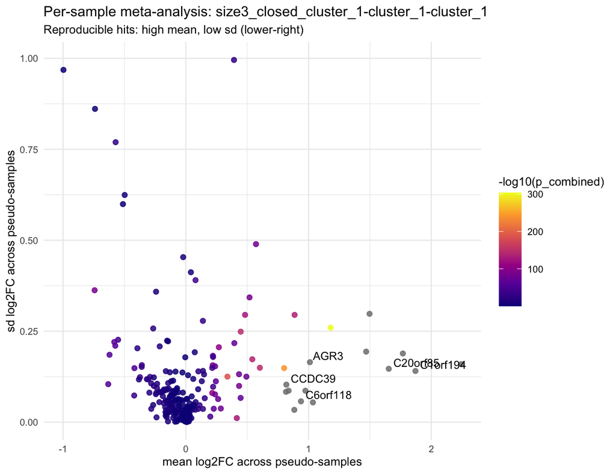

```r
plot_dt <- res_meta[motif_id == target_motif &
                    n_samples_tested >= 2L]
top5 <- head(plot_dt[order(p_combined)], 5L)

ggplot(plot_dt, aes(x = mean_log2FC, y = sd_log2FC)) +
  geom_point(aes(color = -log10(p_combined)), size = 1.6,
             alpha = 0.85) +
  scale_color_viridis_c(option = "plasma") +
  geom_text(data = top5, aes(label = gene),
            hjust = -0.1, vjust = -0.3, size = 3) +
  labs(x = "mean log2FC across pseudo-samples",
       y = "sd log2FC across pseudo-samples",
       color = "-log10(p_combined)",
       title = sprintf("Per-sample meta-analysis: %s",
                       target_motif),
       subtitle = "Reproducible hits: high mean, low sd (lower-right)") +
  theme_minimal(base_size = 9)
```

Comparing the top genes from the two pooling modes makes the rank shift visible — pooled mode concatenates all cells and can let a single-sample driver float to the top, whereas per-sample mode demotes it:

```r
top_pooled <- head(res_pooled[motif_id == target_motif][order(p)],
                   10)[, .(gene, log2FC_pooled = log2FC,
                           p_adj_pooled = p_adj_BH)]
top_meta <- head(res_meta[motif_id == target_motif][
  order(p_combined)], 10)[, .(gene, mean_log2FC, sd_log2FC,
                              p_adj_meta = p_adj_BH)]
merge(top_pooled, top_meta, by = "gene", all = TRUE)[
  order(p_adj_meta)
]
```

```
#>         gene log2FC_pooled p_adj_pooled mean_log2FC  sd_log2FC p_adj_meta
#>       <char>         <num>        <num>       <num>      <num>      <num>
#>  1:     AGR3     1.0304923            0   1.0108979 0.16492186          0
#>  2: C1orf194            NA           NA   1.8704537 0.14070902          0
#>  3: C20orf85            NA           NA   1.6532115 0.14674685          0
#>  4: C6orf118            NA           NA   0.9377982 0.05728080          0
#>  5:   CCDC39            NA           NA   0.8189570 0.10321319          0
#>  6:   CCDC78            NA           NA   0.8375643 0.08655776          0
#>  7:   CFAP53            NA           NA   0.8837745 0.03394241          0
#>  8:    CLIC6            NA           NA   1.0353138 0.05435111          0
#>  9:   CYP4B1            NA           NA   1.4966446 0.29777633          0
#> 10:   DNAAF1            NA           NA   1.7680505 0.18879145          0
#> 11:   ADAM28     0.5341222            0          NA         NA         NA
#> 12:  ADAMTS1    -0.4236434            0          NA         NA         NA
#> 13:  ALDH1A3     0.2226948            0          NA         NA         NA
#> 14:    AMY2A     0.4210172            0          NA         NA         NA
#> 15:   APCDD1     0.2938771            0          NA         NA         NA
#> 16:     AQP3     0.2740790            0          NA         NA         NA
#> 17:  ARFGEF3     0.2721664            0          NA         NA         NA
#> 18:    BAMBI     0.1029023            0          NA         NA         NA
#> 19:    BASP1     0.9593276            0          NA         NA         NA
```

Because the pseudo-samples come from the same slide, most reproducible signals stay strong in both modes (small `sd_log2FC`). On a real multi-sample dataset the same code would surface genes whose spatial motif association replicates across patients/samples — the canonical biological-validation step before reporting motif-driven gene findings.

## 9. Per-niche motif distributions

`subset_region()` produces a per-niche `SpatialGraph` (only edges with both endpoints inside the niche survive); `compare_motifs()` then performs a chi-square test of motif-by-niche independence:

```r
sg_n <- list(
  niche_1 = subset_region(sg, region_id == "niche_1"),
  niche_2 = subset_region(sg, region_id == "niche_2"),
  niche_3 = subset_region(sg, region_id == "niche_3")
)
m_n <- lapply(sg_n, find_motifs, size = 3L)
cmp <- compare_motifs(m_n)
head(cmp, 6)[,
  .(motif_id, count_niche_1, count_niche_2, count_niche_3,
    chi2, p_adj_BH)]
```

```
#>                                      motif_id count_niche_1 count_niche_2
#>                                        <char>         <int>         <int>
#> 1:   size3_open_cluster_1-cluster_1_cluster_1             0          8387
#> 2:   size3_open_cluster_4-cluster_4_cluster_4             3             4
#> 3: size3_closed_cluster_1-cluster_1-cluster_1             0          2789
#> 4: size3_closed_cluster_4-cluster_4-cluster_4             2             0
#> 5:   size3_open_cluster_4-cluster_5_cluster_4            20             2
#> 6:   size3_open_cluster_1-cluster_4_cluster_1             0           614
#>    count_niche_3      chi2 p_adj_BH
#>            <int>     <num>    <num>
#> 1:             0 49829.621        0
#> 2:         11960 44393.187        0
#> 3:             2 16554.399        0
#> 4:          3983 14786.008        0
#> 5:          1554  5649.466        0
#> 6:            29  3432.902        0
```

A heatmap of the top 20 most niche-divergent motifs makes the “each niche has its own motif signature” story visible at a glance. Each row is row-normalized so the colors show what fraction of a motif’s instances live in each niche:

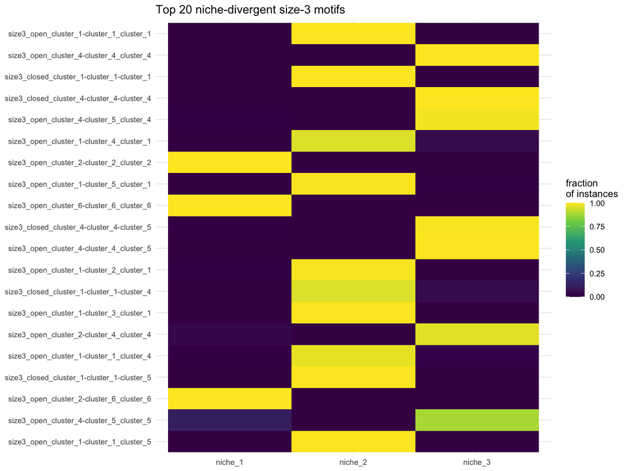

```r
top_n <- 20L
top_cmp <- head(cmp, top_n)
hm_long <- data.table::melt(
  top_cmp[, .(motif_id, niche_1 = count_niche_1,
              niche_2 = count_niche_2, niche_3 = count_niche_3)],
  id.vars = "motif_id", variable.name = "niche", value.name = "count"
)
hm_long[, prop := count / sum(count), by = motif_id]
hm_long[, motif_id := factor(motif_id, levels = rev(top_cmp$motif_id))]

ggplot(hm_long, aes(x = niche, y = motif_id, fill = prop)) +
  geom_tile() +
  scale_fill_viridis_c(limits = c(0, 1)) +
  labs(x = NULL, y = NULL,
       fill = "fraction\nof instances",
       title = sprintf("Top %d niche-divergent size-3 motifs", top_n)) +
  theme_minimal(base_size = 9) +
  theme(axis.text.y = element_text(size = 7))
```

## 10. Niche-defining motifs in physical space

Picking one niche-defining motif per niche and mapping their cells side by side shows the spatial signature of each niche:

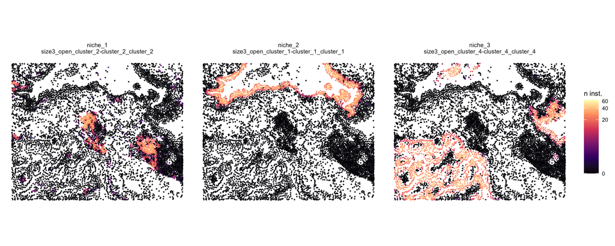

```r
top_per_niche <- function(cmp, niche_col) {
  cnt <- cmp[[niche_col]]
  other <- rowSums(cmp[, .(count_niche_1, count_niche_2, count_niche_3)]) - cnt
  cmp[order(-(cnt - other))][1L, motif_id]
}

motifs_to_show <- c(
  niche_1 = top_per_niche(cmp, "count_niche_1"),
  niche_2 = top_per_niche(cmp, "count_niche_2"),
  niche_3 = top_per_niche(cmp, "count_niche_3")
)

facet_data <- data.table::rbindlist(lapply(seq_along(motifs_to_show),
  function(i) {
    md <- motif_density(m3, motifs_to_show[i])
    data.table::data.table(
      md,
      facet = sprintf("%s\n%s",
                      names(motifs_to_show)[i], motifs_to_show[i])
    )
  }))

ggplot(facet_data, aes(x = x, y = y, color = n_instances)) +
  geom_point(size = 0.35, alpha = 0.85) +
  scale_color_viridis_c(option = "magma", trans = "log1p") +
  coord_fixed() +
  facet_wrap(~ facet, ncol = 3L) +
  labs(color = "n inst.") +
  theme_minimal(base_size = 8) +
  theme(strip.text = element_text(size = 7),
        axis.title = element_blank(),
        axis.text = element_blank(),
        panel.grid = element_blank())
```

The three panels tile the slide cleanly: each niche’s defining motif lights up just that niche’s footprint. This is the “spatial domain signature” view — you can see at a glance which 3-cell pattern marks which region of tissue.

## 11. Cross-niche bridging motifs

```r
mixed <- cmp[
  grepl("cluster_(1|2|4).*cluster_(1|2|4)", motif_id) &
  !grepl("(cluster_1[-_]cluster_1[-_]cluster_1)|(cluster_2[-_]cluster_2[-_]cluster_2)|(cluster_4[-_]cluster_4[-_]cluster_4)",
         motif_id) &
  total >= 200L
]
head(mixed[order(-chi2)], 5)[,
  .(motif_id, count_niche_1, count_niche_2, count_niche_3, total, chi2)]
```

```
#>                                      motif_id count_niche_1 count_niche_2
#>                                        <char>         <int>         <int>
#> 1:   size3_open_cluster_4-cluster_5_cluster_4            20             2
#> 2:   size3_open_cluster_1-cluster_4_cluster_1             0           614
#> 3:   size3_open_cluster_1-cluster_5_cluster_1             0           442
#> 4: size3_closed_cluster_4-cluster_4-cluster_5             3             0
#> 5:   size3_open_cluster_4-cluster_4_cluster_5             0             0
#>    count_niche_3 total     chi2
#>            <int> <num>    <num>
#> 1:          1554  1576 5649.466
#> 2:            29   643 3432.902
#> 3:             3   445 2602.463
#> 4:           569   572 2096.872
#> 5:           517   517 1920.731
```

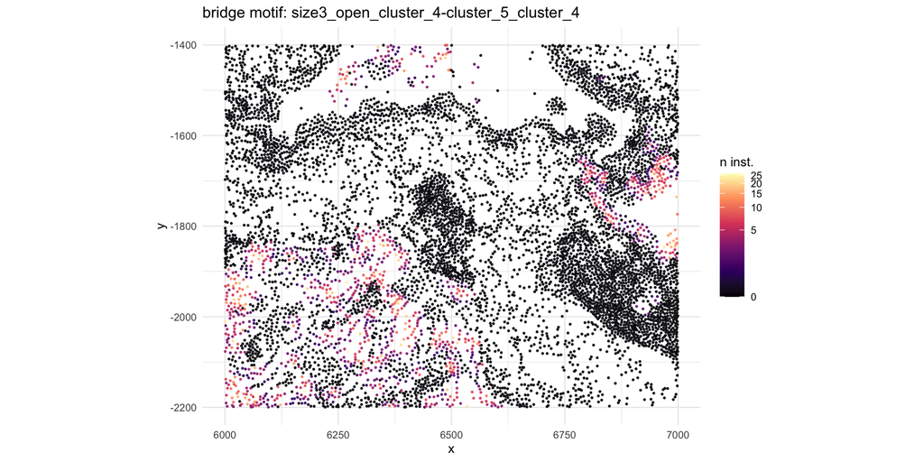

```r
bridge_id <- mixed[order(-chi2)][1L, motif_id]
bridge_density <- motif_density(m3, bridge_id)
ggplot(bridge_density, aes(x = x, y = y, color = n_instances)) +
  geom_point(size = 0.4, alpha = 0.85) +
  scale_color_viridis_c(option = "magma", trans = "log1p") +
  coord_fixed() +
  labs(title = sprintf("bridge motif: %s", bridge_id), color = "n inst.") +
  theme_minimal(base_size = 9)
```

## 12. Bar chart of the most common size-3 motifs

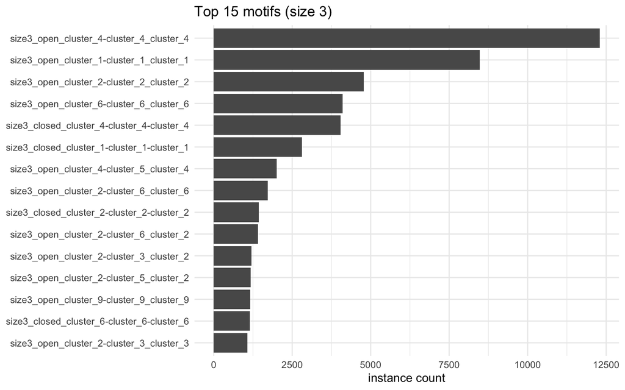

```r
plot(m3, top = 15L)
```